# Simulation examples

# Introduction to Simulations

Simulation is a powerful tool for approximating or deriving quantities that may be difficult to calculate mathematically. Typically, the simulation procedure involves running multiple trials that mimick the experimental setting. To set up simulations, consider the following steps:

1. **Define the context**
   - What information are we given?
   - What are the events we are dealing with?
   - What assumptions do we make?
2. **Identify the question of interest**: what questions would we like to answer with our simulations? Are we interested in a probability or proportion? What about the mean?
3. **Simulate**: define a procedure that mimicks the context of the experiment.
   - Random components can be generated through random number generators or sampling methods.
   - Is there a stopping criteria?
   - What data should be recorded in order to answer the question of interest? Conduct the simulation defined in part 3 a large number of times (1,000; 10,000, etc. ) and record the outcomes.
4. **Analyze simulation data**: use the data generated to answer the question of interest.

Below we give a few examples of simulation problems.

# Game of risk

### Context

A game of risk takes two players, Attacker and Defender. Each **game** consists of $N=100$ wars between Attacker and Defender. Each **war** consists of:

- Rolling a die: Attacker rolls 3 dice and Defender rolls 2 dice
  - Attacker outcome: $(A_1, A_2, A_3)$, $A_i \in \{1,2,3,4,5,6\}$ for $i=1,2,3$,
  - Defender outcome: $(D_1, D_2)$, $D_i \in \{1,2,3,4,5,6\}$ for $i=1,2$.
- Battle 1: Attacker’s highest roll goes against Defender’s highest roll. Possible outcomes:
  - Attacker wins; score $+1$,
  - Attacker loses; score $-1$,
  - ties; score $0$.
- Battle 2: Attacker’s second highest roll goes against Defender’s lowest roll. Possible outcomes same as above:
  - Attacker wins; score $+1$,
  - Attacker loses; score $-1$,
  - ties; score $0$.

The **final game score** is the sum of all partial scores from all $N=100$ wars:

- If the final score is positive, then the game result is in the favor of the Attacker.
- If the final score is negative, then the game result is in the favor of the Defender.

### Simulation goal

Answer the question: is the game in the favor of the Attacker, Defender or none?

### Simulation code

Note:

- We run a simulation of **multiple games** and summarize results of a game out of all simulation runs.
- We use seed (`set.seed(20201013)`) for reproducibility of simulation results.

````r
## Number of simulation repetitions
N_rep <- 1000

## Number of wars in a single game
N_wars <- 100

## Vector to store results from each game simulation repetition
rep_result_vec <-  rep(NA, N_rep)

## Set seed for reproducibility of the results
set.seed(20201013)

for (rep_i in 1:N_rep) {
  ## Note we defined R Markdown code chunk as
  ## ```{r, message = FALSE}
  ## hence the message will not be included in generated PDF/HTML file output
  message(rep_i)

  ## Initial score of a game (from attacker perspective)
  # in current simulation repetition
  game_i_res <- 0

  ## In each simulation repetition, we simulate one full game := 100 wars
  for (war_i in 1:N_wars){

    ## Rolling a die
    attacker_roll <- sample(1:6, size = 3, replace = TRUE)
    defender_roll <- sample(1:6, size = 2, replace = TRUE)

    ## Sort dice roll results
    attacker_roll_sort <- sort(attacker_roll, decreasing = TRUE)
    defender_roll_sort <- sort(defender_roll, decreasing = TRUE)

    ## Battle 1
    battle1_diff <- attacker_roll_sort[1] - defender_roll_sort[1]
    ## Update game score (from attacker perspective)
    if (battle1_diff > 0){
      game_i_res <- game_i_res + 1
    } else if (battle1_diff < 0){
      game_i_res <- game_i_res -1
    }

    ## Battle 2
    battle2_diff <- attacker_roll_sort[2] - defender_roll_sort[2]
    ## Update game score (from attacker perspective)
    if (battle2_diff > 0){
      game_i_res <- game_i_res + 1
    } else if (battle2_diff < 0){
      game_i_res <- game_i_res - 1
    }
  }

  ## Store the result of this one particular game
  rep_result_vec[rep_i] <- game_i_res
}
````

### Analyze simulation data

```r
## Display summary of game repetitions results
summary(rep_result_vec)
```

```
##    Min. 1st Qu.  Median    Mean 3rd Qu.    Max.
##    10.0    47.0    57.5    57.4    67.0    99.0
```

```r
## Another summary: quantiles
quantile(rep_result_vec, probs = c(0.05, 0.25, 0.5, 0.75, 0.95))
```

```
##   5%  25%  50%  75%  95%
## 35.0 47.0 57.5 67.0 81.0
```

### Result

Simulation results suggest that the game is in the favor of the Attacker.

# Some potentially helpful simulation `R` code lines

### sapply

`sapply(X, FUN)` - returns a vector of the same length as `X`, each element of which is the result of applying function `FUN` to the corresponding element of `X`

```r
set.seed(1)
vec <- rnorm(10)
vec
```

```
##  [1] -0.6264538  0.1836433 -0.8356286  1.5952808  0.3295078 -0.8204684
##  [7]  0.4874291  0.7383247  0.5757814 -0.3053884
```

```r
sapply(vec, function(x) ceiling(x))
```

```
##  [1] 0 1 0 2 1 0 1 1 1 0
```

```r
sapply(vec, function(x) floor(x))
```

```
##  [1] -1  0 -1  1  0 -1  0  0  0 -1
```

```r
## sapply with the use of pre-defined function
my_func <- function(k, add_val){
  ceiling(k + add_val)
}

sapply(vec, function(x) my_func(x, 10))
```

```
##  [1] 10 11 10 12 11 10 11 11 11 10
```

### apply

`apply(X, MARGIN, FUN, ...)` - Returns a vector (or array or list) of values obtained by applying a function to margins of an array or matrix.

```r
set.seed(1)
mat_p <- 10
mat_n <- 30
mat <- matrix(data = rnorm(n = mat_p * mat_n), nrow = mat_n)
dim(mat)
```

```
## [1] 30 10
```

```r
apply(mat, 1, function(row) mean(row))
```

```
##  [1]  0.158823194  0.540703951  0.006083858  0.009377425  0.103619465
##  [6] -0.035967747 -0.374001532 -0.062164142 -0.273197652  0.467146770
## [11]  0.031169092 -0.095510793  0.125806205 -0.352556840 -0.403444665
## [16]  0.287627105 -0.189544501 -0.043256221  0.178850199  0.318029683
## [21]  0.049076632 -0.035724203  0.272402127 -0.616290901  0.214259172
## [26]  0.388285398  0.466619802 -0.188465153  0.139864746 -0.080092222
```

```r
apply(mat, 2, function(col) max(col))
```

```
##  [1] 1.595281 1.980400 2.401618 1.767287 2.087167 2.307978 2.497662 1.803142
##  [9] 1.719627 2.649167
```

Example: simulate $R=10,000$ samples of size $n=10$ from $Bernoulli(p=0.2)$. Compute $R$ corresponding sample means. Summarize distribution of sample means.

```r
R <- 10000
sample_n <- 10
prob_p <- 0.2

set.seed(1)
# rbinom's size argument defines number of Bernoulli trials in 1 Binomial random variable
# setting "size = 1" gives 1 Bernoulli trial (= 1 Bernoulli random variable)
mat_data_vec <- rbinom(n = (sample_n * R), size = 1, prob = prob_p)
mat <- matrix(data = mat_data_vec, nrow = R)
dim(mat)
```

```
## [1] 10000    10
```

```r
sample_means <- apply(mat, 1, mean)
length(sample_means)
```

```
## [1] 10000
```

```r
c(mean(sample_means), sd(sample_means), var(sample_means))
```

```
## [1] 0.20041000 0.12657975 0.01602243
```

```r
# theoretical standard deviation of Bernoulli sample mean: \sqrt(\sigma^2/N)
sigma2 <- (prob_p * (1-prob_p))
sqrt(sigma2 / sample_n)
```

```
## [1] 0.1264911
```

```r
# theoretical variance of Bernoulli sample mean: \sigma^2/N
sigma2 / sample_n
```

```
## [1] 0.016
```

### replicate

`replicate(n, expr)` function repeats a given function (`expr`) a specified number of times (`n`).

- Example: make $R=10,000$ samples with replacement from an observed vector of data.

```r
sample_n <- 10
R <- 10000

set.seed(123)
# an observed vector of data
vec_obs <- rnorm(sample_n)
# make R samples with replacement from an observed vector of data
vec_obs_resamples <- replicate(R, sample(vec_obs, size = sample_n, replace = TRUE))
dim(vec_obs_resamples)
```

```
## [1]    10 10000
```

# Mean of the sequence of i.i.d. Gamma variables

- Suppose you are interested in the **mean of sequence of independent, identically distributed Gamma variables** $X_1,\ldots,X_N$.
- From Central Limit Theorem (CLT; Lecture 8) we know that:

  *For our purposes, the CLT states that the distribution of averages of iid variables, properly normalized, becomes that of a standard normal as the sample size increases*

  (Note it holds for **any** iid [“independend identically distributed”] variables, and it is this example-specific that we use $X_i$’s from Gamma distribution; see next example for Beta distribution).
- The Gamma distribution with parameters $shape = k$ and $scale = \theta$ has density given by:
  $$f(x)= \frac{1}{ \Gamma(k)\theta^k} x^{(k-1)} e^{-\frac{x}{\theta}}$$
  and mean and standard deviation given by:
  $$\begin{align}
  E [ X ] & = k \theta \\
  var [ X ] & = k \theta^2 \\
  sd [ X ] & = \sqrt{k \theta^2}.
  \end{align}$$
- From Central Limit Theorem (CLT; Lecture 8) we know that, abusing the notation, we have

$$\begin{aligned}
\overline{X}_n & \to N(E [ X ], var [ X ]/n).
\overline{X}_n & \to N(k \theta, k \theta^2/n).
\end{aligned}$$

Let us see how CLT works in practice. To see this, we are going to simulate **many** $\overline{X}_n$’s (here: $10,000$) and observe if simulated values have the normal distribution which the CLT tells.

Let us see how it works in practice.

```r
# sample size
sample_n <- 20
# simulation repetition number
rep_n <- 10000

## Gamma distribution: parameters
k <- 2
theta <- 10

## Gamma distribution: theoretical mean and sd
(X_mean <- k * theta)
```

```
## [1] 20
```

```r
(X_var  <- k * theta^2)
```

```
## [1] 200
```

```r
(X_sample_mean_var <- X_var/sample_n)
```

```
## [1] 10
```

```r
set.seed(1)
X_mat_vals <- rgamma(n = (rep_n * sample_n), shape = k, scale = theta)
X_mat      <- matrix(X_mat_vals, nrow = rep_n)
dim(X_mat)
```

```
## [1] 10000    20
```

```r
# Compute sample means
X_sample_means <- apply(X_mat, 1, mean)

## Describe distribution of mean values
## Simulation value
c(mean(X_sample_means),  var(X_sample_means))
```

```
## [1] 19.98635 10.03223
```

```r
## Theoretical value from CLT
c(X_mean, X_sample_mean_var)
```

```
## [1] 20 10
```

```r
library(ggplot2)
plt_df <- data.frame(x = X_sample_means)
head(plt_df)
```

```
##          x
## 1 15.76888
## 2 16.76143
## 3 23.35984
## 4 16.48643
## 5 27.41849
## 6 20.68905
```

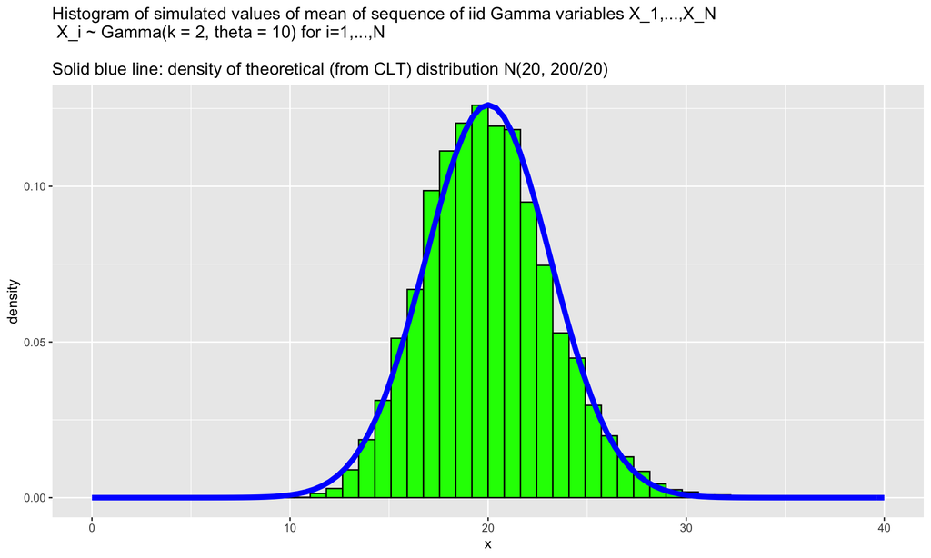

```r
ggplot(plt_df, aes(x = x)) +
  geom_histogram(aes(y = ..density..), fill = "green", color = "black", bins = 50) +
  stat_function(
    fun = dnorm, args = list(mean = X_mean, sd = sqrt(X_sample_mean_var)),
    color = "blue", size = 2) +
  labs(title = "Histogram of simulated values of mean of sequence of iid Gamma variables X_1,...,X_N\n X_i ~ Gamma(k = 2, theta = 10) for i=1,...,N\n\nSolid blue line: density of theoretical (from CLT) distribution N(20, 200/20)") +
  scale_x_continuous(limits = c(0, 40))
```

# The Birthday Paradox (3.4.2 in the textbook)

In a given room what is the probability that at least two people have the same birthday (not necessarily the same year)? Assume that birthdays occur randomly and with the same probability throughout the year, and suppose all years have 365 days.

What is the probability that two people in a room of 23 people share the same birthday? What about in a room of 57 people?

### The Birthday Paradox

```r
# Set seed for reproducibility
set.seed(7654098)

# Define simulation using a function
#     Input:  n_ppl = number of people in the room
#             n_sim = number of simulations
#     Output: estimated probability that 2 people have the same birthday
birthdays <- function(n_ppl, n_sim){

  # Vector of indicators for all simulations_ Values in the vector are
  #     1 if there are at least two people with the same birthday in the simulation
  #     0 if no one has the same birthday
  same_bday <- rep(NA, n_sim)

  # simulations
  for(i in 1:n_sim){
    # Vector of birthdays for everyone in the room
    bdays <- sample(1:365, n_ppl, replace = TRUE)

    # Count the total number of unique bdays
    bday_counts <- length(unique(bdays))

    # Indicate whether at least two people had the same birthday
    #     If the length < num_people, then at least 2 people had the same birthday
    same_bday[i] <- (bday_counts < n_ppl)
  }

  # Return proportion of simulations where at least 2 people had the same birthday
  mean(same_bday)
}

# Run simulation for n_ppl = 23
birthdays(23, 10000)
```

```
## [1] 0.5132
```

```r
# Run simulation for n_ppl = 57
birthdays(57, 10000)
```

```
## [1] 0.9897
```

Thus we see that if there are 23 people in room, there is a approximately a 50% chance that at least two people have the same birthday. Once the number of people in the room increases to 57, there is an approximately 99% chance that at least two people share a birthday.

# Extra Problems

### Gambler’s Ruin

Suppose Alice has $6, Bob has $4, and the two decided to play a betting game involving a fair coin (i.e $P(Heads) = P(Tails) = 0.5$).

- If the coin lands on heads, then Alice wins and Bob gives Alice $1.
- If the coin lands on tails, then Bob wins and Alice gives Bob $1.

The game ends when Alice or Bob has no money. What is the probability that Alice wins the betting game?

### Penney’s Game

Consider a game played between two players, Alan and Beth, using a fair coin. Alan and Beth each selects a sequence of heads and tails. A coin is flipped repeated until one of the two selected patterns emerge. Whomevers pattern emerges first wins.

1. Suppose Alan picks `HH` and Beth picks `HT`. Is the game fair?
2. Now instead, suppose Alan wins if the sequence `HHT` appears before Beth’s sequence, `THH`. What are the odds that Beth wins?
3. Seeing that Beth wins more frequently, Alan changes his sequence to `THH`. Beth thus selects the new pattern `TTH`. What are the odds that Beth wins?

# Solutions to Extra Problems

### Gambler’s Ruin

```r
# Set seed for reproducibility
set.seed(12345)

# Define parameters
n_games <- 10000    # Number of games played/simulations
a_wins <- 0         # Number of games where Alice wins

# Simulation
for(i in 1:n_games){
  # Set initial money balances
  a.balance <- 6
  b.balance <- 4

  # play the game until someone is at no money
  while(a.balance > 0 & b.balance > 0){
    # Flip the coin - can use `sample` since coin is fair
    #     1 indicates heads
    #     2 indicates tails
    flip <- sample(1:2, 1)

    # If heads, Alice wins $1, Bob loses $1
    # If tails, Bob wins $1, Alice loses $1
    if(flip == 1){
      a.balance <- a.balance + 1
      b.balance <- b.balance -1
    } else{
      a.balance <- a.balance -1
      b.balance <- b.balance +1
    }
  }

  # Add 1 to Alice's number of wins if she has all $10 while Bob has $0
  if(a.balance == 10){a_wins <- a_wins + 1}
}

# Give estimated probability Alice wins
a_wins/n_games
```

```
## [1] 0.6114
```

We see that Alice wins the game approximately 60% of the time. This result can be generalized to show a player’s chances of winning/going bankrupt depends on the proportion of money the player has. That is, the player starting with the least amount of money has the highest probability of going bankrupt. This reflects the logic of casinos as casinos have more money than individual players, so the casino expects to “win” most of the time.

### Penney’s Game

#### Part a

```r
# Set seed for reproducibility
set.seed(12345)

n_sims <- 100000    # Number of simulations
a_wins <- 0         # Number of games won by Alan

# Simulation
for(i in 1:n_sims){
  # Get the first coin toss: 1 is heads, 0 is tails
  flip.prev <- rbinom(1, 1, 0.5)

  # Play the game until one of the two patterns show up
  repeat{
    # Current flip
    flip.curr <- rbinom(1, 1, 0.5)

    # Check if one of the two patterns is satisfied
    #     If the pattern is now HH, then Alan wins
    #     If the pattern is now HT, then Beth wins
    # Otherwise keep playing
    if(flip.prev == 1 & flip.curr == 1){
      a_wins <- a_wins + 1
      break
    } else if (flip.prev == 1 & flip.curr == 0){
      break
    }

    # Assign current flip to previous flip
    flip.prev <- flip.curr
  }
}

# Return proportion of games won by Alan
a_wins/n_sims
```

```
## [1] 0.50091
```

From our simulation, we can see that the game is fair.

#### Part b

```r
# Set seed for reproducibility
set.seed(12345)

n_sims <- 100000    # Number of simulations
a_wins <- 0         # Number of games won by Alan

# Simulation
for(i in 1:n_sims){
  # Get the first and second coin toss: 1 is heads, 0 is tails
  flip.prev1 <- rbinom(1, 1, 0.5)
  flip.prev2 <- rbinom(1, 1, 0.5)

  # Play the game until one of the two patterns show up
  repeat{
    # Current flip
    flip.curr <- rbinom(1, 1, 0.5)

    # Check if one of the two patterns is satisfied
    #     If the pattern is now HHT, then Alan wins
    #     If the pattern is now THH, then Beth wins
    # Otherwise keep playing
    if(flip.prev1 == 1 & flip.prev2 == 1 & flip.curr == 0){
      a_wins <- a_wins + 1
      break
    } else if (flip.prev1 == 0 & flip.prev2 == 1 & flip.curr == 1){
      break
    }

    # Assign current flip to previous flip
    flip.prev1 <- flip.prev2
    flip.prev2 <- flip.curr
  }
}

# Return the odds that beth wins
(n_sims-a_wins)/a_wins
```

```
## [1] 3.015097
```

Beth has approximately a 3-1 odds of winning.

#### Part c

```r
# Set seed for reproducibility
set.seed(12345)

n_sims <- 100000    # Number of simulations
a_wins <- 0         # Number of games won by Alan

# Simulation
for(i in 1:n_sims){
  # Get the first and second coin toss: 1 is heads, 0 is tails
  flip.prev1 <- rbinom(1, 1, 0.5)
  flip.prev2 <- rbinom(1, 1, 0.5)

  # Play the game until one of the two patterns show up
  repeat{
    # Current flip
    flip.curr <- rbinom(1, 1, 0.5)

    # Check if one of the two patterns is satisfied
    #     If the pattern is now THH, then Alan wins
    #     If the pattern is now TTH, then Beth wins
    # Otherwise keep playing
    if(flip.prev1 == 0 & flip.prev2 == 1 & flip.curr == 1){
      a_wins <- a_wins + 1
      break
    } else if (flip.prev1 == 0 & flip.prev2 == 0 & flip.curr == 1){
      break
    }

    # Assign current flip to previous flip
    flip.prev1 <- flip.prev2
    flip.prev2 <- flip.curr
  }
}

# Return the odds that beth wins
(n_sims-a_wins)/a_wins
```

```
## [1] 1.992847
```

Again, Beth is favored as her odds of winning are 2 to 1. Interestingly, for any 3 letter pattern, we can find another 3 letter pattern of flips that is more favored. For more, see [here](https://en.wikipedia.org/wiki/Penney's_game).